## Project Outline:

### An Exploration of Gender Differences in Sharing Behavior on Scratch

#### Emilia Gan – COM 521, Winter 2017

## 1. Rationale

It is well known that women are underrepresented in computer science and other computational fields. Previous research has suggested that boys and girls interact with the Scratch programming language and the online Scratch community in different ways. Scratch is the first experience with programming for many, if not most, children. The attitudes towards programming formed by children using the Scratch online programming platform thus likely affect future decisions such as whether to study computational fields or to pursue careers in tech.

The online Scratch platform provides Scratchers with a rich social environment that can influence how they view themselves as programmers and how they grow and develop their skills. Programs created using Scratch can be shared online, making them fully viewable by all others on the Scratch platform. Members of the Scratch community provide feedback on projects and may even remix portions of others’ projects in their own creations. Participating fully in the Scratch online community offers developing programmers resources and support that should enhance their learning.

Our study will examine the differences in project sharing behavior between girls and boys using the Scratch platform. In particular, we will investigate whether there are differences in the sharing patterns of male versus female users and look into whether differences exist in the peer feedback received by projects based on the gender of the project creator. We are especially interested in determining if female Scratchers are less likely to share their projects and whether they are more sensitive to the feedback received by the projects they do share.

## 2. Objectives

### General Objective

To examine how peer recognition of shared projects affects future project sharing behavior by the same Scratcher.

### Specific Objectives

1. To determine whether there are differences in the pattern of Scratch project creation and sharing between male and female users of the Scratch online programming platform.
2. To determine if there is a difference in the frequency of receiving peer feedback between projects created by female users and projects created by male users.
3. To determine if receiving peer feedback (e.g. love-its and comments) affects the future sharing behavior of the project creator.

### Null Hypotheses

To explore the objectives stated above, we will test the following hypotheses:

1. Projects created by females are just as likely to be shared as projects created by males.
2. Projects created by females are just as likely to receive peer recognition as projects created by males.
3. Scratchers whose shared projects receive no peer recognition are just as likely to share future projects as are Scratchers whose earlier shared projects did receive peer recognition.
4. Female Scratchers whose shared projects receive no peer recognition are just as likely to share future projects as are male Scratchers whose shared projects receive no peer recognition.

## 3. Conceptual Diagrams

### Conceptual Diagram 1: Project Outcomes

The first conceptual diagram depicts the possible outcomes for a newly created project.

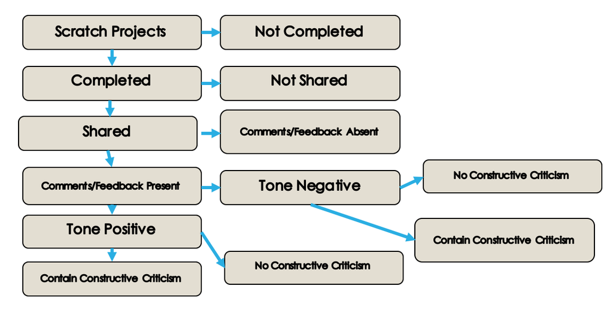

Conceptual Diagram for Potential Outcomes following Project Creation.

### Conceptual Diagram 2: Factors Potentially Influencing Project Sharing

The second conceptual diagram depicts the factors that may contribute to the decision to share or not share a project.

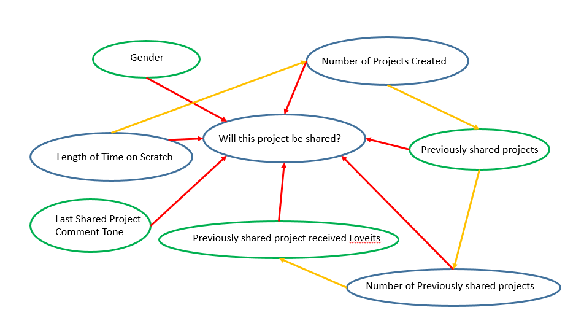

Conceptual Diagram for Factors Potentially Influencing Sharing